# Project: Investigating The Movie Database (TMDb) Dataset

- Introduction
- Data Wrangling
- Exploratory Data Analysis
- Conclusions
- Limitations

## Introduction

This dataset contains information about 10,000 movies collected from The **Movie Database** (TMDb)

### About TMDb:

TMDb in a nutshell is a TV and movie database with a social network flavor.

> The Movie Database (TMDb) is a community built movie and TV database. Every piece of data has been added by our amazing community dating back to 2008. TMDb's strong international focus and breadth of data is largely unmatched and something we're incredibly proud of. Put simply, we live and breathe community and that's precisely what makes us different. [TMDb website](https://www.themoviedb.org/about)

### Columns Description:

1. **id** : identification number for the movie in TMDb.
2. **imdb_id** : identification number for the movie in IMDB.
3. **popularity** : this one is complicated. according to TMDb [description](https://developers.themoviedb.org/3/getting-started/popularity) , it could mean many things. for example in case of movies it could be:
   - Number of votes for the day
   - Number of views for the day
   - Number of users who marked it as a "favourite" for the day
   - Number of users who added it to their "watchlist" for the day
   - Release date
   - Number of total votes
   - Previous days score

     unfortunately, in this dataset we don't have a specific information about what popularity actually represent.
4. **budget** : the movie's designated budget.
5. **revenue** : amount of movie returns.
6. **original_title** : the title of the movie.
7. **cast** : names of actors and actresses in the movie.
8. **homepage** : homepage address for the movie website.
9. **director** : name of the director of the movie.
10. **tagline** : a popular phrase associated with the movie.
11. **keywords** : thematic words describing the movie.
12. **overview** : a short description of what a movie is about.
13. **runtime** : movie runtime in minutes.
14. **genres** : the movie genre or genres to which a movie belongs.
15. **production_companies** : name of production companies for a movie.
16. **release_date** : exact release date of the movie.
17. **vote_count** : number of votes by users for a movie.
18. **vote_average** : the average score of the users' vote for a movie.
19. **release_year** : year of release of the movie.
20. **budget_adj** : budget of the associated movie in terms of 2010 dollars, accounting for inflation over time.
21. **revenue_adj** : revenue of the associated movie in terms of 2010 dollars, accounting for inflation over time.

### Questions to explore:

There is a lot of information that this dataset can provide us. Here we will explore and search for answers to some chosen questions which are listed below:

1. How did several genres fare through the years?
2. Does a high budget guarantee a high revenue? and which movie has the highest budget to revenue ratio?
3. Does a movie runtime affect the revenue? and is the average movie runtime increasing over the years?
4. Who is the most accomplished director in terms of total revenues and total average scores of his movies?
5. Who are the most productive directors in terms of number of movies made?

Now let's get ready and load our libraries.

```python
import numpy as np
import pandas as pd
import matplotlib.pyplot as plt
import seaborn as sns
%matplotlib inline
sns.set_style(style="darkgrid")
```

We also used the magic command of matplotlib inline so that we can see our visuals without calling `plt.show()` everytime. and we also set the visual background to seaborn's good looking one.

## Data Wrangling

Let's now load our dataset and get acquainted with it.

### General Properties

```python
# Loading the dataset then inspecting its first three rows
df = pd.read_csv("tmdb-movies.csv")
```

```python
# displaying the first 3 rows in the dataset
df.head(3)
```

|  | id | imdb_id | popularity | budget | revenue | original_title | cast | homepage | director | tagline | ... | overview | runtime | genres | production_companies | release_date | vote_count | vote_average | release_year | budget_adj | revenue_adj |
| --- | --- | --- | --- | --- | --- | --- | --- | --- | --- | --- | --- | --- | --- | --- | --- | --- | --- | --- | --- | --- | --- |
| 0 | 135397 | tt0369610 | 32.985763 | 150000000 | 1513528810 | Jurassic World | Chris Pratt\|Bryce Dallas Howard\|Irrfan Khan\|Vi... | http://www.jurassicworld.com/ | Colin Trevorrow | The park is open. | ... | Twenty-two years after the events of Jurassic ... | 124 | Action\|Adventure\|Science Fiction\|Thriller | Universal Studios\|Amblin Entertainment\|Legenda... | 6/9/15 | 5562 | 6.5 | 2015 | 1.379999e+08 | 1.392446e+09 |
| 1 | 76341 | tt1392190 | 28.419936 | 150000000 | 378436354 | Mad Max: Fury Road | Tom Hardy\|Charlize Theron\|Hugh Keays-Byrne\|Nic... | http://www.madmaxmovie.com/ | George Miller | What a Lovely Day. | ... | An apocalyptic story set in the furthest reach... | 120 | Action\|Adventure\|Science Fiction\|Thriller | Village Roadshow Pictures\|Kennedy Miller Produ... | 5/13/15 | 6185 | 7.1 | 2015 | 1.379999e+08 | 3.481613e+08 |
| 2 | 262500 | tt2908446 | 13.112507 | 110000000 | 295238201 | Insurgent | Shailene Woodley\|Theo James\|Kate Winslet\|Ansel... | http://www.thedivergentseries.movie/#insurgent | Robert Schwentke | One Choice Can Destroy You | ... | Beatrice Prior must confront her inner demons ... | 119 | Adventure\|Science Fiction\|Thriller | Summit Entertainment\|Mandeville Films\|Red Wago... | 3/18/15 | 2480 | 6.3 | 2015 | 1.012000e+08 | 2.716190e+08 |

3 rows × 21 columns

We got a general idea of what this dataset looks like. There are too many columns (21 actually as we can see from the partial summary provided at the end of our little peek at the dataframe in the previous cell) to be displayed here, so let's get more specific by first checking how many rows and columns we have and then get back to what these columns are.

```python
# inspecting the shape of our dataframe
df.shape
```

```
(10866, 21)
```

So yes we have as many as 21 columns and about 10,000 (10,866 to be exact) rows each representing a movie. now to the columns, what do we have here?

```python
# displaying the columns using a for loop
for i, v in enumerate(df.columns):
    print(i,v)
```

```
0 id
1 imdb_id
2 popularity
3 budget
4 revenue
5 original_title
6 cast
7 homepage
8 director
9 tagline
10 keywords
11 overview
12 runtime
13 genres
14 production_companies
15 release_date
16 vote_count
17 vote_average
18 release_year
19 budget_adj
20 revenue_adj
```

Column names looks intuitive and named properly, no further renaming will be required. We can also use `.columns` attribute to view the columns.

```python
# displaying the columns using columns attribute
df.columns
```

```
Index(['id', 'imdb_id', 'popularity', 'budget', 'revenue', 'original_title',
       'cast', 'homepage', 'director', 'tagline', 'keywords', 'overview',
       'runtime', 'genres', 'production_companies', 'release_date',
       'vote_count', 'vote_average', 'release_year', 'budget_adj',
       'revenue_adj'],
      dtype='object')
```

The for loop way is just more eye friendly as we can see. and now that we got our columns served, let's find out more about the data they represent.

```python
# checking for the datatype of each column
df.dtypes
```

```
id                        int64
imdb_id                  object
popularity              float64
budget                    int64
revenue                   int64
original_title           object
cast                     object
homepage                 object
director                 object
tagline                  object
keywords                 object
overview                 object
runtime                   int64
genres                   object
production_companies     object
release_date             object
vote_count                int64
vote_average            float64
release_year              int64
budget_adj              float64
revenue_adj             float64
dtype: object
```

Great! every column datatype is almost as it should be. now lets have some more detailed information about each column and see whither they have any missing data...or not.

```python
# checking for missing data in the dataset
df.info()
```

```
<class 'pandas.core.frame.DataFrame'>
RangeIndex: 10866 entries, 0 to 10865
Data columns (total 21 columns):
id                      10866 non-null int64
imdb_id                 10856 non-null object
popularity              10866 non-null float64
budget                  10866 non-null int64
revenue                 10866 non-null int64
original_title          10866 non-null object
cast                    10790 non-null object
homepage                2936 non-null object
director                10822 non-null object
tagline                 8042 non-null object
keywords                9373 non-null object
overview                10862 non-null object
runtime                 10866 non-null int64
genres                  10843 non-null object
production_companies    9836 non-null object
release_date            10866 non-null object
vote_count              10866 non-null int64
vote_average            10866 non-null float64
release_year            10866 non-null int64
budget_adj              10866 non-null float64
revenue_adj             10866 non-null float64
dtypes: float64(4), int64(6), object(11)
memory usage: 1.7+ MB
```

```python
# checking for number of unique values
df.nunique()
```

```
id                      10865
imdb_id                 10855
popularity              10814
budget                    557
revenue                  4702
original_title          10571
cast                    10719
homepage                 2896
director                 5067
tagline                  7997
keywords                 8804
overview                10847
runtime                   247
genres                   2039
production_companies     7445
release_date             5909
vote_count               1289
vote_average               72
release_year               56
budget_adj               2614
revenue_adj              4840
dtype: int64
```

```python
# summary statistics
df.describe()
```

|  | id | popularity | budget | revenue | runtime | vote_count | vote_average | release_year | budget_adj | revenue_adj |
| --- | --- | --- | --- | --- | --- | --- | --- | --- | --- | --- |
| count | 10866.000000 | 10866.000000 | 1.086600e+04 | 1.086600e+04 | 10866.000000 | 10866.000000 | 10866.000000 | 10866.000000 | 1.086600e+04 | 1.086600e+04 |
| mean | 66064.177434 | 0.646441 | 1.462570e+07 | 3.982332e+07 | 102.070863 | 217.389748 | 5.974922 | 2001.322658 | 1.755104e+07 | 5.136436e+07 |
| std | 92130.136561 | 1.000185 | 3.091321e+07 | 1.170035e+08 | 31.381405 | 575.619058 | 0.935142 | 12.812941 | 3.430616e+07 | 1.446325e+08 |
| min | 5.000000 | 0.000065 | 0.000000e+00 | 0.000000e+00 | 0.000000 | 10.000000 | 1.500000 | 1960.000000 | 0.000000e+00 | 0.000000e+00 |
| 25% | 10596.250000 | 0.207583 | 0.000000e+00 | 0.000000e+00 | 90.000000 | 17.000000 | 5.400000 | 1995.000000 | 0.000000e+00 | 0.000000e+00 |
| 50% | 20669.000000 | 0.383856 | 0.000000e+00 | 0.000000e+00 | 99.000000 | 38.000000 | 6.000000 | 2006.000000 | 0.000000e+00 | 0.000000e+00 |
| 75% | 75610.000000 | 0.713817 | 1.500000e+07 | 2.400000e+07 | 111.000000 | 145.750000 | 6.600000 | 2011.000000 | 2.085325e+07 | 3.369710e+07 |
| max | 417859.000000 | 32.985763 | 4.250000e+08 | 2.781506e+09 | 900.000000 | 9767.000000 | 9.200000 | 2015.000000 | 4.250000e+08 | 2.827124e+09 |

As seen above, for some columns, this summary statistics can be meaningless.for example, `id` and `release_year`. but for others it gives us a general idea of how the data in these columns looks like.

Also, from the output above we can notice a strange thing: the median for `budget` and `revenue` columns and their adjusted counterparts, is zero, which does not make sense and indicate that zeros are too common in these columns, way too common. what I think is that, these zeros represent missing data in these columns. lest's have a look at them.

```python
# checking for zero value in budget and revenue columns
df.query('budget == 0 | revenue == 0')
```

|  | id | imdb_id | popularity | budget | revenue | original_title | cast | homepage | director | tagline | ... | overview | runtime | genres | production_companies | release_date | vote_count | vote_average | release_year | budget_adj | revenue_adj |
| --- | --- | --- | --- | --- | --- | --- | --- | --- | --- | --- | --- | --- | --- | --- | --- | --- | --- | --- | --- | --- | --- |
| 30 | 280996 | tt3168230 | 3.927333 | 0 | 29355203 | Mr. Holmes | Ian McKellen\|Milo Parker\|Laura Linney\|Hattie M... | http://www.mrholmesfilm.com/ | Bill Condon | The man behind the myth | ... | The story is set in 1947, following a long-ret... | 103 | Mystery\|Drama | BBC Films\|See-Saw Films\|FilmNation Entertainme... | 6/19/15 | 425 | 6.4 | 2015 | 0.000000e+00 | 2.700677e+07 |
| 36 | 339527 | tt1291570 | 3.358321 | 0 | 22354572 | Solace | Abbie Cornish\|Jeffrey Dean Morgan\|Colin Farrel... | NaN | Afonso Poyart | A serial killer who can see your future, a psy... | ... | A psychic doctor, John Clancy, works with an F... | 101 | Crime\|Drama\|Mystery | Eden Rock Media\|FilmNation Entertainment\|Flynn... | 9/3/15 | 474 | 6.2 | 2015 | 0.000000e+00 | 2.056620e+07 |
| 48 | 265208 | tt2231253 | 2.932340 | 30000000 | 0 | Wild Card | Jason Statham\|Michael Angarano\|Milo Ventimigli... | NaN | Simon West | Never bet against a man with a killer hand. | ... | When a Las Vegas bodyguard with lethal skills ... | 92 | Thriller\|Crime\|Drama | Current Entertainment\|Lionsgate\|Sierra / Affin... | 1/14/15 | 481 | 5.3 | 2015 | 2.759999e+07 | 0.000000e+00 |
| 67 | 334074 | tt3247714 | 2.331636 | 20000000 | 0 | Survivor | Pierce Brosnan\|Milla Jovovich\|Dylan McDermott\|... | http://survivormovie.com/ | James McTeigue | His Next Target is Now Hunting Him | ... | A Foreign Service Officer in London tries to p... | 96 | Crime\|Thriller\|Action | Nu Image Films\|Winkler Films\|Millennium Films\|... | 5/21/15 | 280 | 5.4 | 2015 | 1.839999e+07 | 0.000000e+00 |
| 72 | 284289 | tt2911668 | 2.272044 | 0 | 45895 | Beyond the Reach | Michael Douglas\|Jeremy Irvine\|Hanna Mangan Law... | NaN | Jean-Baptiste LÃ©onetti | NaN | ... | A high-rolling corporate shark and his impover... | 95 | Thriller | Furthur Films | 4/17/15 | 81 | 5.5 | 2015 | 0.000000e+00 | 4.222338e+04 |
| ... | ... | ... | ... | ... | ... | ... | ... | ... | ... | ... | ... | ... | ... | ... | ... | ... | ... | ... | ... | ... | ... |
| 10861 | 21 | tt0060371 | 0.080598 | 0 | 0 | The Endless Summer | Michael Hynson\|Robert August\|Lord 'Tally Ho' B... | NaN | Bruce Brown | NaN | ... | The Endless Summer, by Bruce Brown, is one of ... | 95 | Documentary | Bruce Brown Films | 6/15/66 | 11 | 7.4 | 1966 | 0.000000e+00 | 0.000000e+00 |
| 10862 | 20379 | tt0060472 | 0.065543 | 0 | 0 | Grand Prix | James Garner\|Eva Marie Saint\|Yves Montand\|Tosh... | NaN | John Frankenheimer | Cinerama sweeps YOU into a drama of speed and ... | ... | Grand Prix driver Pete Aron is fired by his te... | 176 | Action\|Adventure\|Drama | Cherokee Productions\|Joel Productions\|Douglas ... | 12/21/66 | 20 | 5.7 | 1966 | 0.000000e+00 | 0.000000e+00 |
| 10863 | 39768 | tt0060161 | 0.065141 | 0 | 0 | Beregis Avtomobilya | Innokentiy Smoktunovskiy\|Oleg Efremov\|Georgi Z... | NaN | Eldar Ryazanov | NaN | ... | An insurance agent who moonlights as a carthie... | 94 | Mystery\|Comedy | Mosfilm | 1/1/66 | 11 | 6.5 | 1966 | 0.000000e+00 | 0.000000e+00 |
| 10864 | 21449 | tt0061177 | 0.064317 | 0 | 0 | What's Up, Tiger Lily? | Tatsuya Mihashi\|Akiko Wakabayashi\|Mie Hama\|Joh... | NaN | Woody Allen | WOODY ALLEN STRIKES BACK! | ... | In comic Woody Allen's film debut, he took the... | 80 | Action\|Comedy | Benedict Pictures Corp. | 11/2/66 | 22 | 5.4 | 1966 | 0.000000e+00 | 0.000000e+00 |
| 10865 | 22293 | tt0060666 | 0.035919 | 19000 | 0 | Manos: The Hands of Fate | Harold P. Warren\|Tom Neyman\|John Reynolds\|Dian... | NaN | Harold P. Warren | It's Shocking! It's Beyond Your Imagination! | ... | A family gets lost on the road and stumbles up... | 74 | Horror | Norm-Iris | 11/15/66 | 15 | 1.5 | 1966 | 1.276423e+05 | 0.000000e+00 |

7011 rows × 21 columns

Wow! I didn't expect all this! 7011 rows has no data for budget or revenue!. I had much hope for these two columns to be complete with no missing thing.

```python
# checking for duplicate rows
df.duplicated().sum()
```

```
1
```

We can see we have a single duplicate column in our dataframe which we are going to deal with in the next section.

### Data Cleaning

In this section we are going to clean our dataframe to make it more easier to handle. This will consist of:

- Dealing with duplicate rows
- Dealing with missing values
- Creating a modified dataframe in which only columns of interest - according to the questions proposed above - are included.

#### Dealing with duplicate rows

```python
# checking for duplicate rows
sum(df.duplicated())
```

```
1
```

```python
# viewing the duplicate row
df[df.duplicated()]
```

|  | id | imdb_id | popularity | budget | revenue | original_title | cast | homepage | director | tagline | ... | overview | runtime | genres | production_companies | release_date | vote_count | vote_average | release_year | budget_adj | revenue_adj |
| --- | --- | --- | --- | --- | --- | --- | --- | --- | --- | --- | --- | --- | --- | --- | --- | --- | --- | --- | --- | --- | --- |
| 2090 | 42194 | tt0411951 | 0.59643 | 30000000 | 967000 | TEKKEN | Jon Foo\|Kelly Overton\|Cary-Hiroyuki Tagawa\|Ian... | NaN | Dwight H. Little | Survival is no game | ... | In the year of 2039, after World Wars destroy ... | 92 | Crime\|Drama\|Action\|Thriller\|Science Fiction | Namco\|Light Song Films | 3/20/10 | 110 | 5.0 | 2010 | 30000000.0 | 967000.0 |

1 rows × 21 columns

```python
# viewing both duplicates to compare
df.iloc[2089:2091,]
```

|  | id | imdb_id | popularity | budget | revenue | original_title | cast | homepage | director | tagline | ... | overview | runtime | genres | production_companies | release_date | vote_count | vote_average | release_year | budget_adj | revenue_adj |
| --- | --- | --- | --- | --- | --- | --- | --- | --- | --- | --- | --- | --- | --- | --- | --- | --- | --- | --- | --- | --- | --- |
| 2089 | 42194 | tt0411951 | 0.59643 | 30000000 | 967000 | TEKKEN | Jon Foo\|Kelly Overton\|Cary-Hiroyuki Tagawa\|Ian... | NaN | Dwight H. Little | Survival is no game | ... | In the year of 2039, after World Wars destroy ... | 92 | Crime\|Drama\|Action\|Thriller\|Science Fiction | Namco\|Light Song Films | 3/20/10 | 110 | 5.0 | 2010 | 30000000.0 | 967000.0 |
| 2090 | 42194 | tt0411951 | 0.59643 | 30000000 | 967000 | TEKKEN | Jon Foo\|Kelly Overton\|Cary-Hiroyuki Tagawa\|Ian... | NaN | Dwight H. Little | Survival is no game | ... | In the year of 2039, after World Wars destroy ... | 92 | Crime\|Drama\|Action\|Thriller\|Science Fiction | Namco\|Light Song Films | 3/20/10 | 110 | 5.0 | 2010 | 30000000.0 | 967000.0 |

2 rows × 21 columns

We can see they are just the same.so, let's remove this duplicate

```python
# removing the duplicate row
df.drop_duplicates(inplace=True)
```

To make sure the duplicate row was removed, we will check again the number of rows in our dataframe.

```python
# checking the number of rows to make sure duplicate has been removed
df.shape[0]
```

```
10865
```

10865 compared to 10866 from first time we checked which mean the duplicate row was successfully removed.

#### Dealing with missing values

We have missing values in the following columns: `imdb_id`, `cast`, `homepage`, `director`, `tagline`, `keywords`, `overview`, `genres`, and `production_companies`. in addition to that, also we have the zeros in `budget` and `revenue`. of interest to us are `director` and `genres`, so let's see the missing value in both.

```python
# checking for NaN in director column
df[df['director'].isnull()]
```

|  | id | imdb_id | popularity | budget | revenue | original_title | cast | homepage | director | tagline | ... | overview | runtime | genres | production_companies | release_date | vote_count | vote_average | release_year | budget_adj | revenue_adj |
| --- | --- | --- | --- | --- | --- | --- | --- | --- | --- | --- | --- | --- | --- | --- | --- | --- | --- | --- | --- | --- | --- |
| 532 | 320996 | tt4073952 | 0.126594 | 0 | 0 | Iliza Shlesinger: Freezing Hot | Iliza Shlesinger | http://www.iliza.com/freezing-hot.html | NaN | NaN | ... | Smart and brazen comedian Iliza Shlesinger sha... | 71 | Comedy | New Wave Entertainment | 1/23/15 | 14 | 6.6 | 2015 | 0.000000e+00 | 0.000000e+00 |
| 548 | 355131 | NaN | 0.108072 | 0 | 0 | Sense8: Creating the World | Tuppence Middleton\|Bae Doona \|Brian J. Smith\|A... | NaN | NaN | NaN | ... | NaN | 25 | Documentary\|Science Fiction | Netflix | 8/10/15 | 12 | 7.5 | 2015 | 0.000000e+00 | 0.000000e+00 |
| 556 | 321160 | tt3908634 | 0.100910 | 0 | 0 | With This Ring | Regina Hall\|Jill Scott\|Eve\|Brooklyn Sudano\|Dei... | http://www.mylifetime.com/movies/with-this-ring | NaN | NaN | ... | After attending their friend Elise's (Sudano) ... | 105 | Comedy\|Romance | Lifetime Television\|Sony Pictures Television | 1/24/15 | 14 | 6.5 | 2015 | 0.000000e+00 | 0.000000e+00 |
| 1032 | 259910 | tt3591568 | 0.291253 | 0 | 0 | Marvel Studios: Assembling a Universe | Robert Downey Jr.\|Chris Hemsworth\|Chris Evans\|... | NaN | NaN | - | ... | A look at the story behind Marvel Studios and ... | 43 | TV Movie\|Documentary | Marvel Studios\|ABC Studios | 3/18/14 | 32 | 6.3 | 2014 | 0.000000e+00 | 0.000000e+00 |
| 1054 | 253675 | tt3711030 | 0.269468 | 0 | 0 | Unlocking Sherlock | Benedict Cumberbatch\|Martin Freeman\|Steven Mof... | NaN | NaN | NaN | ... | Explore how writers Steven Moffat and Mark Gat... | 60 | TV Movie\|Documentary | NaN | 1/19/14 | 11 | 7.2 | 2014 | 0.000000e+00 | 0.000000e+00 |
| 1203 | 256561 | tt3203290 | 0.119891 | 150000 | 0 | Free to Play | Benedict Lim\|Danil Ishutin\|Clinton Loomis | http://www.freetoplaythemovie.com | NaN | One game will change their lives. | ... | Follow three professional video game players a... | 75 | Documentary | Valve | 3/19/14 | 40 | 7.0 | 2014 | 1.381637e+05 | 0.000000e+00 |
| 1241 | 296370 | tt3024964 | 0.135376 | 0 | 0 | Dance-Off | Kathryn McCormick\|Shane Harper\|Finola Hughes\|C... | NaN | NaN | NaN | ... | DANCE-OFF is a tongue-in-cheek family comedy s... | 0 | Romance\|Music\|Comedy | NaN | 1/1/14 | 18 | 5.7 | 2014 | 0.000000e+00 | 0.000000e+00 |
| 1288 | 301235 | tt4217172 | 0.038364 | 0 | 0 | Top Gear: The Perfect Road Trip 2 | Jeremy Clarkson\|Richard Hammond | NaN | NaN | NaN | ... | In 2013 Jeremy Clarkson and Richard Hammond em... | 94 | Documentary | 2 Entertain Video | 11/17/14 | 12 | 6.8 | 2014 | 0.000000e+00 | 0.000000e+00 |
| 1852 | 133365 | tt1127205 | 0.256703 | 0 | 0 | The Diary of Anne Frank | Ellie Kendrick\|Kate Ashfield\|Geoff Breton\|Feli... | NaN | NaN | NaN | ... | Called the most accurate adaptation of Anne Fr... | 100 | Drama | Darlow Smithson Productions\|British Broadcasti... | 1/9/09 | 19 | 7.5 | 2009 | 0.000000e+00 | 0.000000e+00 |
| 1872 | 26379 | tt1532957 | 0.091395 | 3250000 | 0 | Paa | Amitabh Bachchan\|Abhishek Bachchan\|Vidya Balan... | http://www.paathefilm.com/ | NaN | NaN | ... | He suffers from a progeria like syndrome. Ment... | 133 | Drama\|Family\|Foreign | A B Corp | 12/4/09 | 11 | 6.1 | 2009 | 3.303301e+06 | 0.000000e+00 |
| 1895 | 281979 | tt1413314 | 0.056777 | 0 | 0 | Doctor Who: The Waters of Mars | David Tennant | NaN | NaN | NaN | ... | The Doctor joins forces with his oldest compan... | 62 | Science Fiction\|Adventure\|Family | BBC Wales | 12/19/09 | 25 | 8.0 | 2009 | 0.000000e+00 | 0.000000e+00 |
| 2221 | 48832 | tt1707823 | 0.281852 | 0 | 0 | Scott Pilgrim vs. the Animation | Michael Cera\|Alison Pill\|Georgette Perna\|Mae W... | NaN | NaN | Read the Comic. Watch the Movie. See the Anima... | ... | Scott Pilgrim vs. The Animation is an animated... | 4 | TV Movie\|Animation\|Adventure | Titmouse | 8/10/10 | 19 | 7.7 | 2010 | 0.000000e+00 | 0.000000e+00 |
| 2286 | 47911 | tt1747960 | 0.207234 | 0 | 0 | Bo Burnham: Words, Words, Words | Bo Burnham | NaN | NaN | NaN | ... | Bo Burnham is back with a new one-man show ful... | 63 | Comedy | NaN | 10/19/10 | 13 | 6.5 | 2010 | 0.000000e+00 | 0.000000e+00 |
| 2290 | 51823 | tt1663193 | 0.203502 | 0 | 0 | Across the Line: The Exodus of Charlie Wright | Aidan Quinn\|Andy García\|Mario Van Peebles\|Dan... | NaN | NaN | Redemption has its price. | ... | The story centers on Charlie, a Los Angeles bi... | 94 | Drama\|Action\|Thriller\|Crime | NaN | 12/28/10 | 11 | 6.0 | 2010 | 0.000000e+00 | 0.000000e+00 |
| 2315 | 48373 | tt1274296 | 0.171615 | 0 | 0 | Listen to Your Heart | Alexia Rasmussen\|Kent Moran\|Cybill Shepherd\|Sh... | http://www.listentoyourheartfilm.com/ | NaN | One song can change your life. | ... | Danny Foster doesn't have much: an apartment a... | 0 | Drama\|Music\|Romance | NaN | 8/14/10 | 29 | 7.3 | 2010 | 0.000000e+00 | 0.000000e+00 |
| 2318 | 34134 | tt1610301 | 0.170408 | 0 | 0 | Barbie in A Mermaid Tale | Kelly Sheridan\|Kathleen Barr\|Nakia Burrise\|Gar... | http://www.barbie.com/mermaid-tale/ | NaN | NaN | ... | Barbie stars as Merliah, a surfing champion fr... | 75 | Animation\|Family\|Fantasy | NaN | 1/26/10 | 35 | 6.3 | 2010 | 0.000000e+00 | 0.000000e+00 |
| 2376 | 315620 | tt1672218 | 0.068411 | 0 | 0 | Doctor Who: A Christmas Carol | Matt Smith\|Karen Gillan\|Arthur Darvill\|Michael... | NaN | NaN | NaN | ... | Amy Pond and Rory Williams are trapped on a cr... | 62 | NaN | NaN | 12/25/10 | 11 | 7.7 | 2010 | 0.000000e+00 | 0.000000e+00 |
| 2397 | 241829 | tt1805454 | 0.033048 | 0 | 0 | The Making of The Walking Dead | NaN | NaN | NaN | NaN | ... | The Making of the TV Series The Walking Dead | 30 | Documentary | NaN | 7/31/10 | 42 | 8.4 | 2010 | 0.000000e+00 | 0.000000e+00 |
| 2401 | 45644 | NaN | 0.067753 | 0 | 0 | Opeth: In Live Concert At The Royal Albert Hall | Mikael Åkerfeldt\|Martin "Axe" Axenrot\|Martin ... | http://www.opeth.com | NaN | The Loyal Disharmonic Orchestra, Conducted By ... | ... | As part of the ongoing celebration of their 20... | 163 | Music | NaN | 9/21/10 | 10 | 8.6 | 2010 | 0.000000e+00 | 0.000000e+00 |
| 2403 | 72013 | tt1587157 | 0.067620 | 0 | 0 | Yu-Gi-Oh! 3D: Bonds Beyond Time | Greg Abbey\|Dan Green\|Matthew Charles\|Sean Sche... | NaN | NaN | NaN | ... | After falling through a time-slip, Yusei Fudo ... | 60 | Animation\|Fantasy | NaN | 1/23/10 | 10 | 6.0 | 2010 | 0.000000e+00 | 0.000000e+00 |
| 3171 | 17171 | tt1201984 | 0.019819 | 0 | 0 | The Assassination of Jesse James: Death Of An ... | Ted Levine\|Casey Affleck\|Brad Pitt\|Mary-Louise... | NaN | NaN | NaN | ... | Explores the true story of the notorious Jesse... | 32 | Documentary | New Wave Entertainment | 1/1/08 | 20 | 6.8 | 2008 | 0.000000e+00 | 0.000000e+00 |
| 3224 | 20313 | tt1270491 | 0.224721 | 0 | 0 | John Mayer: Where the Light Is Live in Los Ang... | John Mayer\|Steve Jordan\|Pino Palladino\|David R... | NaN | NaN | NaN | ... | Where The Light Is: John Mayer Live in Los Ang... | 164 | Music | NaN | 7/1/08 | 16 | 8.5 | 2008 | 0.000000e+00 | 0.000000e+00 |
| 3276 | 15467 | tt1105733 | 0.147657 | 4180000 | 11000000 | Kismat Konnection | Shahid Kapoor\|Vidya Balan\|Juhi Chawla\|Om Puri\|... | http://www.kismatkonnection.tips.in/ | NaN | NaN | ... | This is a story about an architect Raj Malhotr... | 153 | Drama\|Comedy\|Romance\|Foreign | Tips Industries | 7/18/08 | 11 | 5.8 | 2008 | 4.233448e+06 | 1.114065e+07 |
| 3285 | 36131 | tt1286750 | 0.136883 | 0 | 0 | Tropic Thunder: Rain of Madness | Justin Theroux\|Jack Black\|Steve Coogan\|Robert ... | NaN | NaN | Before the thunder... comes the madness. | ... | A behind-the-scenes mockumentary of Tropic Thu... | 30 | Action\|Comedy | NaN | 8/26/08 | 12 | 6.9 | 2008 | 0.000000e+00 | 0.000000e+00 |
| 3357 | 32836 | tt1254947 | 0.042517 | 0 | 0 | Bill Burr: Why Do I Do This? | Bill Burr | NaN | NaN | NaN | ... | One of America's fastest-rising comedians, Bil... | 55 | Comedy | NaN | 9/23/08 | 10 | 8.0 | 2008 | 0.000000e+00 | 0.000000e+00 |
| 3365 | 22258 | tt1321823 | 0.002475 | 0 | 0 | Foo Fighters: Live at Wembley Stadium | Dave Grohl\|Nate Mendel\|Chris Shiflett\|Pat Smea... | NaN | NaN | NaN | ... | Foo Fighters captured over their two sold-out ... | 120 | Music | NaN | 8/25/08 | 10 | 8.4 | 2008 | 0.000000e+00 | 0.000000e+00 |
| 3369 | 77974 | tt2014400 | 0.001682 | 0 | 0 | Wizards On Deck With Hannah Montana | NaN | NaN | NaN | NaN | ... | Three Disney Channel shows come together in "W... | 68 | Family | NaN | 2/11/08 | 14 | 6.1 | 2008 | 0.000000e+00 | 0.000000e+00 |
| 3910 | 79976 | tt2096615 | 0.002006 | 0 | 0 | Steve Jobs: One Last Thing | NaN | NaN | NaN | NaN | ... | Through interviews with colleagues and others ... | 60 | Documentary | NaN | 11/2/11 | 11 | 6.6 | 2011 | 0.000000e+00 | 0.000000e+00 |
| 4679 | 91342 | tt2197823 | 0.421746 | 0 | 0 | Barbie in A Mermaid Tale 2 | Nakia Burrise\|Gary Chalk | NaN | NaN | NaN | ... | Surf's up for Barbie as she returns as Merliah... | 74 | Animation\|Family | Mattel | 2/23/12 | 22 | 6.0 | 2012 | 0.000000e+00 | 0.000000e+00 |
| 4797 | 369145 | NaN | 0.167501 | 0 | 0 | Doctor Who: The Snowmen | Matt Smith\|Jenna Coleman\|Richard E. Grant\|Ian ... | NaN | NaN | NaN | ... | Christmas Eve, 1892, and the falling snow is t... | 60 | NaN | BBC Television UK | 12/25/12 | 10 | 7.8 | 2012 | 0.000000e+00 | 0.000000e+00 |
| 4872 | 269177 | NaN | 0.090552 | 0 | 0 | Party Bercy | Florence Foresti | NaN | NaN | NaN | ... | Florence Foresti is offered Bercy tribute to a... | 120 | Comedy | TF1 Vidéo | 9/23/12 | 15 | 6.4 | 2012 | 0.000000e+00 | 0.000000e+00 |
| 4939 | 168219 | tt2167393 | 0.003183 | 0 | 0 | The Men Who Built America | NaN | NaN | NaN | America wasn't discovered. It was built. | ... | John D. Rockefeller, Cornelius Vanderbilt, And... | 360 | Documentary\|History | NaN | 10/16/12 | 11 | 5.3 | 2012 | 0.000000e+00 | 0.000000e+00 |
| 5413 | 20378 | tt0163986 | 0.324270 | 0 | 0 | The Brave Little Toaster to the Rescue | NaN | NaN | NaN | NaN | ... | Those fun-loving eletrical appliances from the... | 74 | Animation\|Comedy\|Family | NaN | 11/1/97 | 11 | 7.0 | 1997 | 0.000000e+00 | 0.000000e+00 |
| 5866 | 246569 | tt2934844 | 0.211825 | 5000000 | 0 | Jinxed | Ciara Bravo\|Jack Griffo\|Jacob Bertrand\|Elena K... | NaN | NaN | NaN | ... | Meet the Murphys, a family with never ending b... | 75 | Family\|Fantasy\|Comedy | NaN | 11/29/13 | 19 | 7.0 | 2013 | 4.680167e+06 | 0.000000e+00 |
| 5915 | 284019 | tt2283584 | 0.168210 | 0 | 0 | Phineas and Ferb: Mission Marvel | Vincent Martella\|Thomas Brodie-Sangster\|Ashley... | http://disneyxd.disney.com/phineas-and-ferb/mi... | NaN | Avengers need Phineas and Ferb to Assemble. | ... | When Dr. Doofenshmirtz's latest invention caus... | 44 | Action\|Adventure\|Science Fiction | Disney Television Animation | 8/16/13 | 13 | 5.9 | 2013 | 0.000000e+00 | 0.000000e+00 |
| 5972 | 238234 | tt3258142 | 0.165605 | 0 | 0 | Top Gear: The Perfect Road Trip | Jeremy Clarkson\|Richard Hammond | NaN | NaN | Seven days, more than 1,000 miles, 20 cars, tw... | ... | The aim: to select the ideal mode of transport... | 84 | TV Movie\|Action\|Adventure\|Documentary | BBC | 11/17/13 | 35 | 7.6 | 2013 | 0.000000e+00 | 0.000000e+00 |
| 6033 | 238185 | tt3397430 | 0.048587 | 0 | 0 | Russell Brand: Messiah Complex | Russell Brand | http://www.russellbrand.com/2013/11/messiah-co... | NaN | NaN | ... | Recorded live at Hammersmith Apollo, Russell q... | 99 | Comedy | NaN | 11/25/13 | 12 | 6.8 | 2013 | 0.000000e+00 | 0.000000e+00 |
| 6181 | 18729 | tt0088583 | 0.000065 | 0 | 0 | North and South, Book I | Patrick Swayze\|Philip Casnoff\|Kirstie Alley\|Ge... | NaN | NaN | NaN | ... | Two friends, one northern and one southern, st... | 561 | Drama\|History\|Western | NaN | 11/3/85 | 17 | 6.0 | 1985 | 0.000000e+00 | 0.000000e+00 |
| 7579 | 58432 | tt0484273 | 0.443952 | 0 | 0 | La hora fría | Silke\|Omar Muñoz\|Pepo Oliva\|Carola Manzanares... | NaN | NaN | NaN | ... | The eight years boy Jesús has been living in ... | 92 | Horror\|Thriller\|Science Fiction\|Mystery\|Foreign | NaN | 9/14/07 | 10 | 4.9 | 2007 | 0.000000e+00 | 0.000000e+00 |
| 7767 | 282758 | tt0827573 | 0.126603 | 0 | 0 | Doctor Who: The Runaway Bride | David Tennant\|Catherine Tate | NaN | NaN | NaN | ... | A young bride in the midst of her wedding find... | 60 | Science Fiction\|TV Movie | NaN | 7/6/07 | 18 | 7.6 | 2007 | 0.000000e+00 | 0.000000e+00 |
| 7814 | 25565 | tt1236486 | 0.040311 | 0 | 0 | Transformers: Beginnings | Peter Cullen\|Frank Welker\|Mark Ryan\|Patrick Ha... | NaN | NaN | NaN | ... | On their home planet of Cybertron, the Autobot... | 22 | Animation\|Action\|Thriller\|Science Fiction | DreamWorks Home Entertainment | 10/16/07 | 34 | 5.8 | 2007 | 0.000000e+00 | 0.000000e+00 |
| 9593 | 46188 | tt0220698 | 0.001662 | 0 | 0 | Peter Pan | NaN | NaN | NaN | NaN | ... | This animated fairy tale for kids tells the cl... | 52 | Action\|Adventure\|Animation\|Family\|Fantasy | Burbank Films Australia | 1/1/88 | 28 | 6.6 | 1988 | 0.000000e+00 | 0.000000e+00 |
| 10386 | 225804 | tt1028555 | 0.118854 | 0 | 0 | The Making of 'The Nightmare Before Christmas' | Mike Belzer\|Tim Burton\|Bonita DeCarlo\|Greg Dyk... | NaN | NaN | NaN | ... | The Making of Tim Burton and Henry Selick's 19... | 25 | Documentary | Buena Vista Home Entertainment | 10/3/93 | 15 | 7.5 | 1993 | 0.000000e+00 | 0.000000e+00 |
| 10426 | 34038 | tt0061937 | 0.114034 | 0 | 0 | Magical Mystery Tour | John Lennon\|Paul McCartney\|George Harrison\|Rin... | NaN | NaN | NaN | ... | A typically Beatlesque film originally produce... | 55 | Music | MPI Home Video | 12/25/67 | 15 | 5.8 | 1967 | 0.000000e+00 | 0.000000e+00 |

44 rows × 21 columns

```python
# checking for NaN in genres column
df[df['genres'].isnull()]
```

|  | id | imdb_id | popularity | budget | revenue | original_title | cast | homepage | director | tagline | ... | overview | runtime | genres | production_companies | release_date | vote_count | vote_average | release_year | budget_adj | revenue_adj |
| --- | --- | --- | --- | --- | --- | --- | --- | --- | --- | --- | --- | --- | --- | --- | --- | --- | --- | --- | --- | --- | --- |
| 424 | 363869 | tt4835298 | 0.244648 | 0 | 0 | Belli di papÃ | Diego Abatantuono\|Matilde Gioli\|Andrea Pisani\|... | NaN | Guido Chiesa | NaN | ... | Italian remake of the Mexican 2013 hit, "We th... | 100 | NaN | NaN | 10/29/15 | 21 | 6.1 | 2015 | 0.00000 | 0.0 |
| 620 | 361043 | tt5022680 | 0.129696 | 0 | 0 | All Hallows' Eve 2 | NaN | NaN | Antonio Padovan\|Bryan Norton\|Marc Roussel\|Ryan... | NaN | ... | A woman finds a VHS tape on her doorstep that ... | 90 | NaN | Ruthless Pictures\|Hollywood Shorts | 10/6/15 | 13 | 5.0 | 2015 | 0.00000 | 0.0 |
| 997 | 287663 | NaN | 0.330431 | 0 | 0 | Star Wars Rebels: Spark of Rebellion | Freddie Prinze Jr.\|Vanessa Marshall\|Steve Blum... | NaN | Steward Lee\|Steven G. Lee | NaN | ... | A Long Time Ago In A Galaxy Far, Far Away… A... | 44 | NaN | NaN | 10/3/14 | 13 | 6.8 | 2014 | 0.00000 | 0.0 |
| 1712 | 21634 | tt1073510 | 0.302095 | 0 | 0 | Prayers for Bobby | Ryan Kelley\|Sigourney Weaver\|Henry Czerny\|Dan ... | http://www.prayersforbobby.com/ | Russell Mulcahy | Before you echo "amen" in your home and place ... | ... | True story of Mary Griffith, gay rights crusad... | 88 | NaN | Daniel Sladek Entertainment | 2/27/09 | 57 | 7.4 | 2009 | 0.00000 | 0.0 |
| 1897 | 40534 | tt1229827 | 0.020701 | 0 | 0 | Jonas Brothers: The Concert Experience | Nick Jonas\|Joe Jonas\|Kevin Jonas\|John Lloyd Ta... | NaN | Bruce Hendricks | NaN | ... | Secure your VIP pass to a once-in-a-lifetime e... | 76 | NaN | NaN | 2/27/09 | 11 | 7.0 | 2009 | 0.00000 | 0.0 |
| 2370 | 127717 | tt1525359 | 0.081892 | 0 | 0 | Freshman Father | Britt Irvin\|Merrilyn Gann\|Barbara Tyson\|Anthon... | NaN | Michael Scott | NaN | ... | NaN | 0 | NaN | NaN | 6/5/10 | 12 | 5.8 | 2010 | 0.00000 | 0.0 |
| 2376 | 315620 | tt1672218 | 0.068411 | 0 | 0 | Doctor Who: A Christmas Carol | Matt Smith\|Karen Gillan\|Arthur Darvill\|Michael... | NaN | NaN | NaN | ... | Amy Pond and Rory Williams are trapped on a cr... | 62 | NaN | NaN | 12/25/10 | 11 | 7.7 | 2010 | 0.00000 | 0.0 |
| 2853 | 57892 | tt0270053 | 0.130018 | 0 | 0 | Vizontele | YÄ±lmaz ErdoÄŸan\|Demet Akbag\|Altan Erkekli\|Cem... | NaN | YÄ±lmaz ErdoÄŸan | NaN | ... | The story takes place in a small town (called ... | 110 | NaN | NaN | 2/2/01 | 12 | 7.2 | 2001 | 0.00000 | 0.0 |
| 3279 | 54330 | tt1720044 | 0.145331 | 0 | 0 | ì•„ê¸°ì™€ ë‚˜ | Jang Keun-suk\|Song Ha-yoon\|Kim Jeong-Nan | NaN | Kim Jin-Yeong | NaN | ... | Joon-soo (Jang Geun -Seok) is a rebellious hig... | 96 | NaN | NaN | 8/13/08 | 11 | 6.1 | 2008 | 0.00000 | 0.0 |
| 4547 | 123024 | tt2305700 | 0.520520 | 0 | 0 | London 2012 Olympic Opening Ceremony: Isles of... | Queen Elizabeth II\|Mike Oldfield\|Kenneth Brana... | http://www.london2012.com/ | Danny Boyle | Inspire a generation. | ... | The London 2012 Olympic Games Opening Ceremony... | 220 | NaN | BBC | 7/27/12 | 12 | 8.3 | 2012 | 0.00000 | 0.0 |
| 4732 | 139463 | tt2084977 | 0.235911 | 0 | 0 | The Scapegoat | Andrew Scott\|Jodhi May\|Eileen Atkins\|Matthew R... | http://www.island-pictures.co.uk/extras/the-sc... | Charles Sturridge | NaN | ... | Set in 1952, as England prepares for the coron... | 100 | NaN | Island Pictures | 9/9/12 | 12 | 6.2 | 2012 | 0.00000 | 0.0 |
| 4797 | 369145 | NaN | 0.167501 | 0 | 0 | Doctor Who: The Snowmen | Matt Smith\|Jenna Coleman\|Richard E. Grant\|Ian ... | NaN | NaN | NaN | ... | Christmas Eve, 1892, and the falling snow is t... | 60 | NaN | BBC Television UK | 12/25/12 | 10 | 7.8 | 2012 | 0.00000 | 0.0 |
| 4890 | 126909 | tt2219564 | 0.083202 | 0 | 0 | Cousin Ben Troop Screening | Jason Schwartzman | http://www.funnyordie.com/videos/fc132ce8b2/co... | Wes Anderson | NaN | ... | Cousin Ben hosts a screening of Wes Anderson's... | 2 | NaN | NaN | 1/1/12 | 14 | 7.0 | 2012 | 0.00000 | 0.0 |
| 5830 | 282848 | tt2986512 | 0.248944 | 0 | 0 | Doctor Who: The Time of the Doctor | Matt Smith\|Jenna Coleman | NaN | James Payne | A change is going to come... | ... | Orbiting a quiet backwater planet, the massed ... | 60 | NaN | NaN | 12/25/13 | 26 | 8.5 | 2013 | 0.00000 | 0.0 |
| 5934 | 200204 | tt2808968 | 0.067433 | 0 | 0 | Prada: Candy | Peter Gadiot\|Rodolphe Pauly\|Léa Seydoux | NaN | Wes Anderson\|Roman Coppola | short | ... | Candy is a modern chic french woman. She meets... | 3 | NaN | NaN | 3/25/13 | 27 | 6.9 | 2013 | 0.00000 | 0.0 |
| 6043 | 190940 | tt2797242 | 0.039080 | 0 | 0 | Bombay Talkies | Aamir Khan\|Rani Mukerji\|Randeep Hooda\|Saqib Sa... | http://en.wikipedia.org/wiki/Bombay_Talkies_%2... | Anurag Kashyap\|Dibakar Banerjee\|Zoya Akhtar\|Ka... | NaN | ... | One hundred years of Hindi cinema is celebrate... | 127 | NaN | Viacom 18 Motion Pictures | 5/3/13 | 12 | 5.9 | 2013 | 0.00000 | 0.0 |
| 6530 | 168891 | tt0818519 | 0.092724 | 0 | 0 | Saw Rebirth | Whit Anderson\|Stan Kirsch\|Jeff Shuter\|George W... | NaN | Jeff Shuter\|Daniel Viney | Somewhere... Somehow... Something went wrong... | ... | This comic, set in the world of SAW goes back ... | 6 | NaN | NaN | 10/24/05 | 24 | 5.9 | 2005 | 0.00000 | 0.0 |
| 8234 | 56804 | tt0114844 | 0.028874 | 0 | 0 | Viaggi di nozze | Carlo Verdone\|Claudia Gerini\|Veronica Pivetti\|... | NaN | Carlo Verdone | NaN | ... | Le vicessitudini di tre coppie di novelli spos... | 103 | NaN | NaN | 12/15/95 | 44 | 6.7 | 1995 | 0.00000 | 0.0 |
| 8614 | 65595 | tt0117880 | 0.273934 | 0 | 0 | T2 3-D: Battle Across Time | Arnold Schwarzenegger\|Linda Hamilton\|Edward Fu... | NaN | James Cameron | NaN | ... | Three freedom fighters attack a large corporat... | 12 | NaN | NaN | 1/1/96 | 14 | 6.7 | 1996 | 0.00000 | 0.0 |
| 8878 | 92208 | tt0250593 | 0.038045 | 0 | 0 | Mom's Got a Date With a Vampire | Matt O'Leary\|Laura Vandervoort\|Myles Jeffrey\|C... | NaN | Steve Boyum | NaN | ... | The Hansen kids are in a jam. Adam and his bes... | 85 | NaN | Walt Disney Pictures | 10/13/00 | 16 | 5.4 | 2000 | 0.00000 | 0.0 |
| 9307 | 141859 | tt0097446 | 0.094652 | 0 | 0 | Goldeneye | Charles Dance\|Phyllis Logan\|Patrick Ryecart\|La... | NaN | Don Boyd | NaN | ... | Fact-based biography of James Bond author, Ian... | 105 | NaN | Anglia Television | 8/26/89 | 10 | 5.3 | 1989 | 0.00000 | 0.0 |
| 9799 | 48847 | tt0193716 | 0.175008 | 0 | 0 | The Amputee | Catherine E. Coulson\|David Lynch | NaN | David Lynch | NaN | ... | A double leg amputated woman sits and writes a... | 5 | NaN | NaN | 1/1/74 | 11 | 5.0 | 1974 | 0.00000 | 0.0 |
| 10659 | 4255 | tt0065904 | 0.344172 | 5000 | 0 | The Party at Kitty and Stud's | Sylvester Stallone\|Henrietta Holm\|Nicholas War... | NaN | Morton Lewis | NaN | ... | Kitty and Stud are lovers. They enjoy a robust... | 71 | NaN | Stallion Releasing Inc. | 2/10/70 | 10 | 3.0 | 1970 | 28081.84172 | 0.0 |

23 rows × 21 columns

Again by checking the results we can see that most of the titles here are TV specials and commercials that can be easily ignored.

We can now say that these rows with missing data can be removed without having a big impact on our analysis. so let's go on with it. only one problem, while removing the rows we showed above will not have big impact on our analysis (44 and 23 rows) and we provided the reason why, removing all NaN rows will leave us with nothing as other columns have NaNs in thousands!.For this we will drop the missing values after creating our modified dataframe.

```python
# removing all rows with NaN values
df.dropna()
```

|  | id | imdb_id | popularity | budget | revenue | original_title | cast | homepage | director | tagline | ... | overview | runtime | genres | production_companies | release_date | vote_count | vote_average | release_year | budget_adj | revenue_adj |
| --- | --- | --- | --- | --- | --- | --- | --- | --- | --- | --- | --- | --- | --- | --- | --- | --- | --- | --- | --- | --- | --- |
| 0 | 135397 | tt0369610 | 32.985763 | 150000000 | 1513528810 | Jurassic World | Chris Pratt\|Bryce Dallas Howard\|Irrfan Khan\|Vi... | http://www.jurassicworld.com/ | Colin Trevorrow | The park is open. | ... | Twenty-two years after the events of Jurassic ... | 124 | Action\|Adventure\|Science Fiction\|Thriller | Universal Studios\|Amblin Entertainment\|Legenda... | 6/9/15 | 5562 | 6.5 | 2015 | 1.379999e+08 | 1.392446e+09 |
| 1 | 76341 | tt1392190 | 28.419936 | 150000000 | 378436354 | Mad Max: Fury Road | Tom Hardy\|Charlize Theron\|Hugh Keays-Byrne\|Nic... | http://www.madmaxmovie.com/ | George Miller | What a Lovely Day. | ... | An apocalyptic story set in the furthest reach... | 120 | Action\|Adventure\|Science Fiction\|Thriller | Village Roadshow Pictures\|Kennedy Miller Produ... | 5/13/15 | 6185 | 7.1 | 2015 | 1.379999e+08 | 3.481613e+08 |
| 2 | 262500 | tt2908446 | 13.112507 | 110000000 | 295238201 | Insurgent | Shailene Woodley\|Theo James\|Kate Winslet\|Ansel... | http://www.thedivergentseries.movie/#insurgent | Robert Schwentke | One Choice Can Destroy You | ... | Beatrice Prior must confront her inner demons ... | 119 | Adventure\|Science Fiction\|Thriller | Summit Entertainment\|Mandeville Films\|Red Wago... | 3/18/15 | 2480 | 6.3 | 2015 | 1.012000e+08 | 2.716190e+08 |
| 3 | 140607 | tt2488496 | 11.173104 | 200000000 | 2068178225 | Star Wars: The Force Awakens | Harrison Ford\|Mark Hamill\|Carrie Fisher\|Adam D... | http://www.starwars.com/films/star-wars-episod... | J.J. Abrams | Every generation has a story. | ... | Thirty years after defeating the Galactic Empi... | 136 | Action\|Adventure\|Science Fiction\|Fantasy | Lucasfilm\|Truenorth Productions\|Bad Robot | 12/15/15 | 5292 | 7.5 | 2015 | 1.839999e+08 | 1.902723e+09 |
| 4 | 168259 | tt2820852 | 9.335014 | 190000000 | 1506249360 | Furious 7 | Vin Diesel\|Paul Walker\|Jason Statham\|Michelle ... | http://www.furious7.com/ | James Wan | Vengeance Hits Home | ... | Deckard Shaw seeks revenge against Dominic Tor... | 137 | Action\|Crime\|Thriller | Universal Pictures\|Original Film\|Media Rights ... | 4/1/15 | 2947 | 7.3 | 2015 | 1.747999e+08 | 1.385749e+09 |
| ... | ... | ... | ... | ... | ... | ... | ... | ... | ... | ... | ... | ... | ... | ... | ... | ... | ... | ... | ... | ... | ... |
| 10724 | 668 | tt0064757 | 1.778746 | 7000000 | 81974493 | On Her Majesty's Secret Service | George Lazenby\|Diana Rigg\|Telly Savalas\|Gabrie... | http://www.mgm.com/view/movie/1411/On-Her-Maje... | Peter R. Hunt | Far up! Far out! Far more! James Bond 007 is b... | ... | James Bond tracks archnemesis Ernst Blofeld to... | 142 | Adventure\|Action\|Thriller | Eon Productions\|Metro-Goldwyn-Mayer (MGM)\|Danjaq | 12/12/69 | 258 | 6.4 | 1969 | 4.160985e+07 | 4.872780e+08 |
| 10759 | 948 | tt0077651 | 1.198849 | 300000 | 70000000 | Halloween | Donald Pleasence\|Jamie Lee Curtis\|P.J. Soles\|N... | http://www.theofficialjohncarpenter.com/hallow... | John Carpenter | The Night HE Came Home! | ... | A psychotic murderer, institutionalized since ... | 91 | Horror\|Thriller | Compass International Pictures\|Falcon Internat... | 10/25/78 | 522 | 7.3 | 1978 | 1.002810e+06 | 2.339890e+08 |
| 10760 | 8469 | tt0077975 | 1.157930 | 2700000 | 141000000 | Animal House | John Belushi\|Tim Matheson\|John Vernon\|Verna Bl... | http://www.animalhouse.com/ | John Landis | It was the Deltas against the rules... the rul... | ... | At a 1962 College, Dean Vernon Wormer is deter... | 109 | Comedy | Universal Pictures\|Oregon Film Factory\|Stage I... | 7/27/78 | 230 | 6.7 | 1978 | 9.025292e+06 | 4.713208e+08 |
| 10817 | 13963 | tt0077838 | 0.064029 | 0 | 321952 | The Last Waltz | Robbie Robertson\|Rick Danko\|Levon Helm\|Richard... | http://www.mgm.com/#/our-titles/1092/The-Last-... | Martin Scorsese | It Started as a Concert. It Became a Celebration. | ... | Martin Scorsese's rockumentary intertwines foo... | 117 | Documentary\|Music | FM Productions\|Last Waltz Inc. | 5/1/78 | 33 | 8.0 | 1978 | 0.000000e+00 | 1.076189e+06 |
| 10819 | 16214 | tt0077696 | 0.044675 | 0 | 78000000 | Hooper | Burt Reynolds\|Robert Klein\|Adam West\|Jan-Micha... | http://en.wikipedia.org/wiki/Hooper_(film) | Hal Needham | The greatest stuntman alive! | ... | Burt Reynolds plays a legendary stunt man know... | 107 | Action\|Comedy | Warner Bros. | 7/28/78 | 13 | 6.0 | 1978 | 0.000000e+00 | 2.607307e+08 |

1992 rows × 21 columns

As said above, will leave us with nothing, 1992 out of 10865 rows.

#### Creating a modified dataframe

before any further steps let's make it easier for us to focus and get rid of columns that will not aid in answering the questions reviewed above. for example, columns like `id` and `imdb_id` will not add any thing to our investigation by creating a new modified dataframe that we can handle freely and keeping our original dataframe intact just in case.

To do this we will use numpy's `r_` function to concatenate the indices of our desired columns, then use pandas `.iloc` for column selection based on that.

```python
# concatenating the columns indices with r_
col_mod = np.r_[5,8,12,13,15:21]

# selecting columns with iloc
df_mod = df.iloc[:,col_mod]
df_mod.head(2)
```

|  | original_title | director | runtime | genres | release_date | vote_count | vote_average | release_year | budget_adj | revenue_adj |
| --- | --- | --- | --- | --- | --- | --- | --- | --- | --- | --- |
| 0 | Jurassic World | Colin Trevorrow | 124 | Action\|Adventure\|Science Fiction\|Thriller | 6/9/15 | 5562 | 6.5 | 2015 | 1.379999e+08 | 1.392446e+09 |
| 1 | Mad Max: Fury Road | George Miller | 120 | Action\|Adventure\|Science Fiction\|Thriller | 5/13/15 | 6185 | 7.1 | 2015 | 1.379999e+08 | 3.481613e+08 |

```python
# checking number of rows and columns in modified dataframe
df_mod.shape
```

```
(10865, 10)
```

All rows are intact with only the columns we selected. now we can return to dealing with missing values.

```python
# removing missing values from the modified dataframe
df_mod = df_mod.dropna()
df_mod.shape
```

```
(10800, 10)
```

This is much better, 10800 out of 10865 rows compared to 1992 out of 10865 rows. we just now need to check that we have no more missing values in our dataframe.

```python
# making sure we have no more NaN
df_mod.isna().sum()
```

```
original_title    0
director          0
runtime           0
genres            0
release_date      0
vote_count        0
vote_average      0
release_year      0
budget_adj        0
revenue_adj       0
dtype: int64
```

Great! no NaN anymore.

## Exploratory Data Analysis

Let's have a summary statistics of our modified dataframe

```python
# summary stats of modified dataframe
df_mod.describe()
```

|  | runtime | vote_count | vote_average | release_year | budget_adj | revenue_adj |
| --- | --- | --- | --- | --- | --- | --- |
| count | 10800.000000 | 10800.000000 | 10800.000000 | 10800.000000 | 1.080000e+04 | 1.080000e+04 |
| mean | 102.189722 | 218.600741 | 5.970880 | 2001.289537 | 1.765437e+07 | 5.167714e+07 |
| std | 30.783873 | 577.165055 | 0.933006 | 12.819545 | 3.438403e+07 | 1.450182e+08 |
| min | 0.000000 | 10.000000 | 1.500000 | 1960.000000 | 0.000000e+00 | 0.000000e+00 |
| 25% | 90.000000 | 17.000000 | 5.400000 | 1995.000000 | 0.000000e+00 | 0.000000e+00 |
| 50% | 99.000000 | 39.000000 | 6.000000 | 2006.000000 | 0.000000e+00 | 0.000000e+00 |
| 75% | 111.250000 | 147.000000 | 6.600000 | 2011.000000 | 2.103337e+07 | 3.408743e+07 |
| max | 900.000000 | 9767.000000 | 9.200000 | 2015.000000 | 4.250000e+08 | 2.827124e+09 |

Now let's have a look at our variables. we will start by looking at the distribution of each variable in the dataframe using pandas's `.hist`

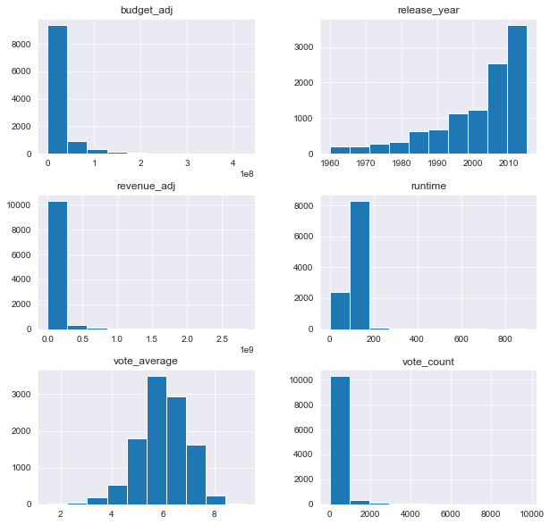

```python
# plotting a histogram to show the distribution of variables
df_mod.hist(figsize=(10,10));
```

Let's have a closer look at three different distributions: `budget_adj` skewed to right, `vote_average` normally distributed, and `release_year` skewed to left.

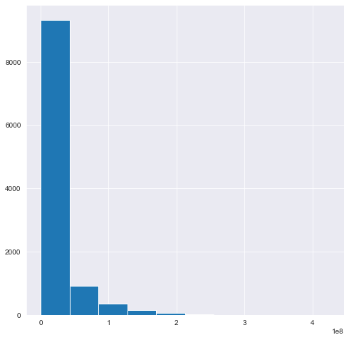

```python
# histogram representing the distribution of budget_adj column
df_mod.budget_adj.hist(figsize=(8,8));
```

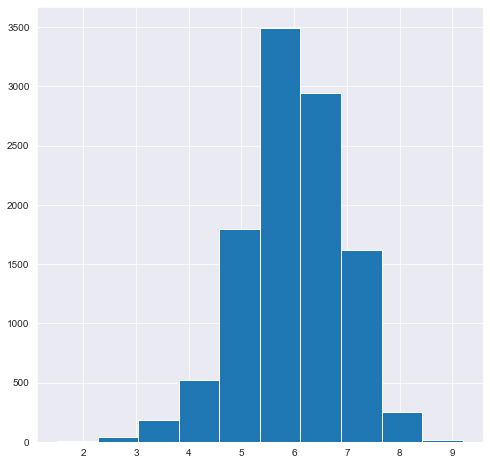

```python
# histogram representing the distribution of of vote_average column
df_mod.vote_average.hist(figsize=(8,8));
```

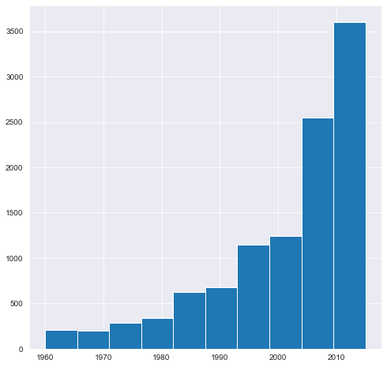

```python
# histogram representing the distribution of release_year column
df_mod.release_year.hist(figsize=(8,8));
```

### 1. How did several genres fare through the years?

In this question we will invesigate the popularity of movie genres by finding the amount of movies in each genres through the year. are they increasing? and with them the popularity of the genre, or are they decreasing? and with them the popularity of the genre.

We will select some genres to track their number of movies through years, our chosen genres are: Action, Comedy, Animation, Horror, Documentary, and Western.

From our look at the dataframe, `genres` column does not look really inviting.

```python
# checking the genres column
df_mod['genres']
```

```
0        Action|Adventure|Science Fiction|Thriller
1        Action|Adventure|Science Fiction|Thriller
2               Adventure|Science Fiction|Thriller
3         Action|Adventure|Science Fiction|Fantasy
4                            Action|Crime|Thriller
                           ...
10861                                  Documentary
10862                       Action|Adventure|Drama
10863                               Mystery|Comedy
10864                                Action|Comedy
10865                                       Horror
Name: genres, Length: 10865, dtype: object
```

each cell in the column contain several genres! which will be a problem in our investigation. Thankfully by searching, I found this [post](https://stackoverflow.com/questions/28121682/quickest-way-to-make-a-get-dummies-type-dataframe-from-a-column-with-a-multiple) on stack overflow, which introduced me to the concept of a dummy variable.

from my understanding, a *dummy varible* is a generated column with a boolean or 0/1 values that indicate the presence or absence of the data which the column represent. this will help not only in separating each unique string in its own column but also will return a numerical one that we can easily manipulate and use in our calculations.

To create this dummy variable we will use pandas `.str.get_dummies()` which I found out how to use from its [documentation](https://pandas.pydata.org/pandas-docs/stable/reference/api/pandas.Series.str.get_dummies.html) . an important part is the separator between strings in each cell, which is a bar "|" in our column and which is also the default separator in `.str.get_dummies()`, so we don't have to provide any arguments.

```python
# creating a dummy dataframe from the genres column
genres = df_mod.genres.str.get_dummies()
genres.head(2)
```

|  | Action | Adventure | Animation | Comedy | Crime | Documentary | Drama | Family | Fantasy | Foreign | History | Horror | Music | Mystery | Romance | Science Fiction | TV Movie | Thriller | War | Western |
| --- | --- | --- | --- | --- | --- | --- | --- | --- | --- | --- | --- | --- | --- | --- | --- | --- | --- | --- | --- | --- |
| 0 | 1 | 1 | 0 | 0 | 0 | 0 | 0 | 0 | 0 | 0 | 0 | 0 | 0 | 0 | 0 | 1 | 0 | 1 | 0 | 0 |
| 1 | 1 | 1 | 0 | 0 | 0 | 0 | 0 | 0 | 0 | 0 | 0 | 0 | 0 | 0 | 0 | 1 | 0 | 1 | 0 | 0 |

Now this looks really great! each genre has its own column that we can easily handle now. but just one thing more, we need to add the `release_year` column to this dataframe, and for this we will use pandas `concat()`. for how to use, this [section](https://pandas.pydata.org/pandas-docs/stable/user_guide/merging.html) from pandas user guide was referenced.

```python
# adding release_year to our dummy dataframe.
genres = pd.concat([df_mod.release_year , genres], axis=1, sort=False)
genres.head(2)
```

|  | release_year | Action | Adventure | Animation | Comedy | Crime | Documentary | Drama | Family | Fantasy | ... | History | Horror | Music | Mystery | Romance | Science Fiction | TV Movie | Thriller | War | Western |
| --- | --- | --- | --- | --- | --- | --- | --- | --- | --- | --- | --- | --- | --- | --- | --- | --- | --- | --- | --- | --- | --- |
| 0 | 2015 | 1 | 1 | 0 | 0 | 0 | 0 | 0 | 0 | 0 | ... | 0 | 0 | 0 | 0 | 0 | 1 | 0 | 1 | 0 | 0 |
| 1 | 2015 | 1 | 1 | 0 | 0 | 0 | 0 | 0 | 0 | 0 | ... | 0 | 0 | 0 | 0 | 0 | 1 | 0 | 1 | 0 | 0 |

2 rows × 21 columns

All is set now. Let's have a look and see first how many movies are in each genre using a bar chart.

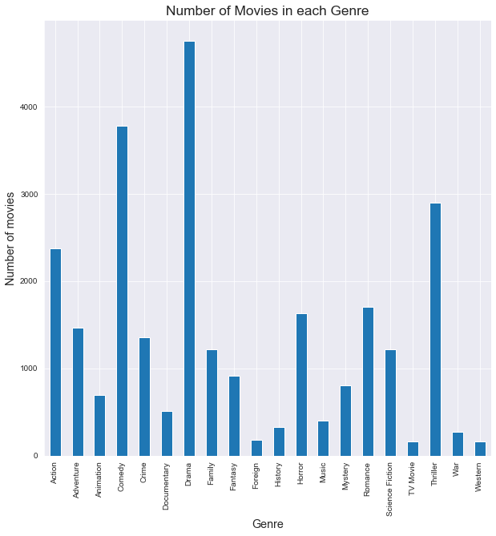

```python
# plotting a bar chart for the total number of movies in each genre
genres.iloc[:,1:].sum().plot.bar(figsize=(10,10))
plt.title('Number of Movies in each Genre', fontsize='xx-large')
plt.xlabel('Genre', fontsize='x-large')
plt.ylabel('Number of movies', fontsize='x-large');
```

From the above chart we see that the drama genre has the most number of movies, and next to it is comedy. genres with least number of movies are foreign, TV movie, and western.

Now we need to get the number of movies in each genre by year. to do this we will use pandas `.groupby()` to group by `release_year` column, then sum the number of movies in each year.

```python
# grouping by release_year then adding the number of movies in each year
genres = genres.groupby('release_year', as_index= False).sum()
genres.head(2)
```

|  | release_year | Action | Adventure | Animation | Comedy | Crime | Documentary | Drama | Family | Fantasy | ... | History | Horror | Music | Mystery | Romance | Science Fiction | TV Movie | Thriller | War | Western |
| --- | --- | --- | --- | --- | --- | --- | --- | --- | --- | --- | --- | --- | --- | --- | --- | --- | --- | --- | --- | --- | --- |
| 0 | 1960 | 8 | 5 | 0 | 8 | 2 | 0 | 13 | 3 | 2 | ... | 5 | 7 | 1 | 0 | 6 | 3 | 0 | 6 | 2 | 6 |
| 1 | 1961 | 7 | 6 | 1 | 10 | 2 | 0 | 16 | 5 | 2 | ... | 3 | 3 | 2 | 1 | 7 | 4 | 0 | 0 | 2 | 3 |

2 rows × 21 columns

We are now ready to create our plot, for which we will use matplotlib `plot` function, to see the change in number of genre movies through the years. and the best kind of chart to visualize change through time is the line chart.

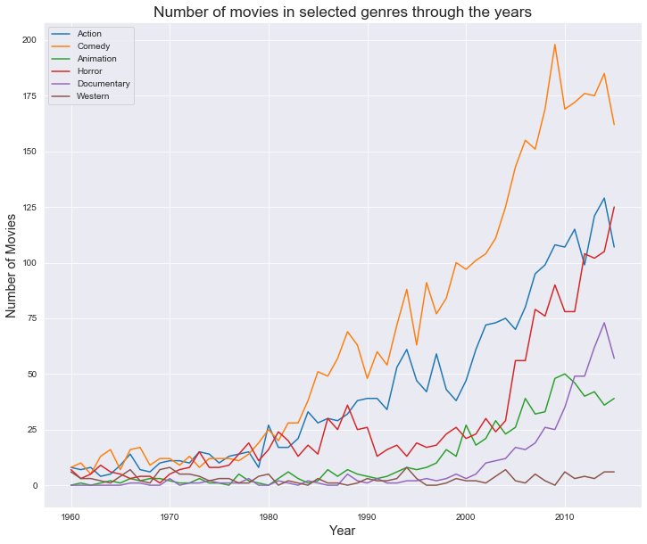

```python
# plotting our line chart
plt.figure(figsize=(12,10))
plt.plot(genres['release_year'],genres['Action'], label='Action')
plt.plot(genres['release_year'],genres['Comedy'], label='Comedy')
plt.plot(genres['release_year'],genres['Animation'], label='Animation')
plt.plot(genres['release_year'],genres['Horror'], label='Horror')
plt.plot(genres['release_year'],genres['Documentary'], label='Documentary')
plt.plot(genres['release_year'],genres['Western'], label='Western')
plt.title('Number of movies in selected genres through the years', fontsize='xx-large')
plt.xlabel('Year', fontsize='x-large')
plt.ylabel('Number of Movies', fontsize='x-large')
plt.legend();
```

From this line chart, all the selected genres are showing an increase in number of movies through the years with some more than others. all except the western genre, which show almost no change. now that is strange, I was expecting a peak during the sixties in the western genre due to the western boom at that time, followed by a sharp fall in number afterwards.but remember our note above, this is due to this dataset is not accurately presenting movies before 2000s.

To answer this question we will create a new budgets dataframe containing the `budget` and `revenue` columns along with the following:

- create a new column named `budget_level` in which we will divide budget into high, middle, and low
- create a new column named `rev_bud_ratio` to explore the relationship between both budget and revenue in a quantified manner. this will involve dividing `revenue_adj` by `budget_adj` which means we can't have zeros in any of them so that we can get a meaningful result.

Let's start by creating budgets dataframe and dealing with zeros in our columns. also scientific notation is not really necessary in this context, so I will convert both `budget_adj` and `revenue_adj` to integers to make it a little bit easier to handle.

**Note**: *we will include also `runtime` and `release_year` in the dataframe because we are going to need them in our following question*

To remove the zero cells in `budget_adj` and `revenue_adj` we will use pandas `.query()` to get all the rows that does not have zero value in both of these columns. and assigning the result to our budgets dataframe.

```python
# creating budgets dataframe
budgets = df_mod.query('budget_adj != 0 & revenue_adj != 0 ')[['original_title','release_year','budget_adj','revenue_adj','runtime']]
budgets
```

|  | original_title | release_year | budget_adj | revenue_adj | runtime |
| --- | --- | --- | --- | --- | --- |
| 0 | Jurassic World | 2015 | 1.379999e+08 | 1.392446e+09 | 124 |
| 1 | Mad Max: Fury Road | 2015 | 1.379999e+08 | 3.481613e+08 | 120 |
| 2 | Insurgent | 2015 | 1.012000e+08 | 2.716190e+08 | 119 |
| 3 | Star Wars: The Force Awakens | 2015 | 1.839999e+08 | 1.902723e+09 | 136 |
| 4 | Furious 7 | 2015 | 1.747999e+08 | 1.385749e+09 | 137 |
| ... | ... | ... | ... | ... | ... |
| 10822 | Who's Afraid of Virginia Woolf? | 1966 | 5.038511e+07 | 2.266436e+08 | 131 |
| 10828 | Torn Curtain | 1966 | 2.015404e+07 | 8.733419e+07 | 128 |
| 10829 | El Dorado | 1966 | 3.125892e+07 | 4.030809e+07 | 120 |
| 10835 | The Sand Pebbles | 1966 | 8.061618e+07 | 1.343603e+08 | 182 |
| 10848 | Fantastic Voyage | 1966 | 3.436265e+07 | 8.061618e+07 | 100 |

Only 3854 rows! but they are the only rows we can work with in case of our question, we can't have zeros while we are dividing columns. and for that let's make sure and check for zeros in our new dataframe.

```python
# making sure we have no zeros
budgets.query('budget_adj == 0 | revenue_adj == 0')
```

|  | original_title | release_year | budget_adj | revenue_adj | runtime |
| --- | --- | --- | --- | --- | --- |

good we have no more zeros. let's now have a look at how the distribution of `budget_adj` will look like.

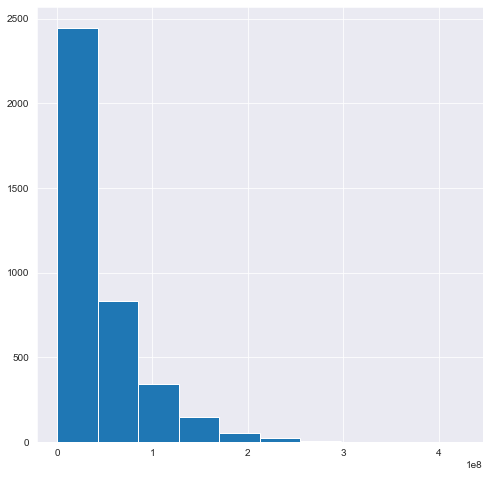

```python
# plotting a histogram to show the distribution of budget_adj after removing zeros
budgets['budget_adj'].hist(figsize=(8,8));
```

still skewed but a big change from the first time.

#### Creating the budget_level column

To create this colum we will do the following:

- movies below median budget will be labelled low.
- movies budgets between the median and the 3rd quartile will be labelled medium
- movies with budgets above the 3rd quartile will be labelled high.

according to the above criteria we create the bin edges and names with which pandas `cut` will work.

So, let's get our `budget_adj` summary statistics now and get going.

```python
# summary stats for budget_adj
budgets['budget_adj'].describe()
```

```
count    3.854000e+03
mean     4.423999e+07
std      4.480925e+07
min      9.693980e-01
25%      1.309053e+07
50%      3.001611e+07
75%      6.061307e+07
max      4.250000e+08
Name: budget_adj, dtype: float64
```

using the above summary we will now create our bin edges.

```python
# creating the bin edges
bin_edges = [9.693980e-01, 3.001611e+07, 6.061307e+07, 4.250000e+08]
```

and now for the bin names.

```python
# creating the bin names
bin_names = ["Low" ,"Medium" ,"High" ]
```

now will will use pandas `cut` to divide the `budget_adj` column according to bin_edges and bin_names and assign the result to our new column `budget_level`.

```python
# dividing budget_adj and creating budget_level
budgets['budget_level'] = pd.cut(budgets['budget_adj'], bin_edges, labels=bin_names)
budgets.head(10)
```

|  | original_title | release_year | budget_adj | revenue_adj | runtime | budget_level |
| --- | --- | --- | --- | --- | --- | --- |
| 0 | Jurassic World | 2015 | 1.379999e+08 | 1.392446e+09 | 124 | High |
| 1 | Mad Max: Fury Road | 2015 | 1.379999e+08 | 3.481613e+08 | 120 | High |
| 2 | Insurgent | 2015 | 1.012000e+08 | 2.716190e+08 | 119 | High |
| 3 | Star Wars: The Force Awakens | 2015 | 1.839999e+08 | 1.902723e+09 | 136 | High |
| 4 | Furious 7 | 2015 | 1.747999e+08 | 1.385749e+09 | 137 | High |
| 5 | The Revenant | 2015 | 1.241999e+08 | 4.903142e+08 | 156 | High |
| 6 | Terminator Genisys | 2015 | 1.425999e+08 | 4.053551e+08 | 125 | High |
| 7 | The Martian | 2015 | 9.935996e+07 | 5.477497e+08 | 141 | High |
| 8 | Minions | 2015 | 6.807997e+07 | 1.064192e+09 | 91 | High |
| 9 | Inside Out | 2015 | 1.609999e+08 | 7.854116e+08 | 94 | High |

#### Creating the rev_bud_ratio column

To create it we will simply divide `revenue_adj` by `budget_adj`.

```python
# creating rev_bud_ratio column
budgets['rev_bud_ratio']= budgets['revenue_adj'] / budgets['budget_adj']
budgets.head(10)
```

|  | original_title | release_year | budget_adj | revenue_adj | runtime | budget_level | rev_bud_ratio |
| --- | --- | --- | --- | --- | --- | --- | --- |
| 0 | Jurassic World | 2015 | 1.379999e+08 | 1.392446e+09 | 124 | High | 10.090192 |
| 1 | Mad Max: Fury Road | 2015 | 1.379999e+08 | 3.481613e+08 | 120 | High | 2.522909 |
| 2 | Insurgent | 2015 | 1.012000e+08 | 2.716190e+08 | 119 | High | 2.683984 |
| 3 | Star Wars: The Force Awakens | 2015 | 1.839999e+08 | 1.902723e+09 | 136 | High | 10.340891 |
| 4 | Furious 7 | 2015 | 1.747999e+08 | 1.385749e+09 | 137 | High | 7.927628 |
| 5 | The Revenant | 2015 | 1.241999e+08 | 4.903142e+08 | 156 | High | 3.947782 |
| 6 | Terminator Genisys | 2015 | 1.425999e+08 | 4.053551e+08 | 125 | High | 2.842603 |
| 7 | The Martian | 2015 | 9.935996e+07 | 5.477497e+08 | 141 | High | 5.512781 |
| 8 | Minions | 2015 | 6.807997e+07 | 1.064192e+09 | 91 | High | 15.631499 |
| 9 | Inside Out | 2015 | 1.609999e+08 | 7.854116e+08 | 94 | High | 4.878335 |

Now that we have all the columns ready, let's have a general look of the relationships between the variables using pandas `plotting.scatter_matrix()`.

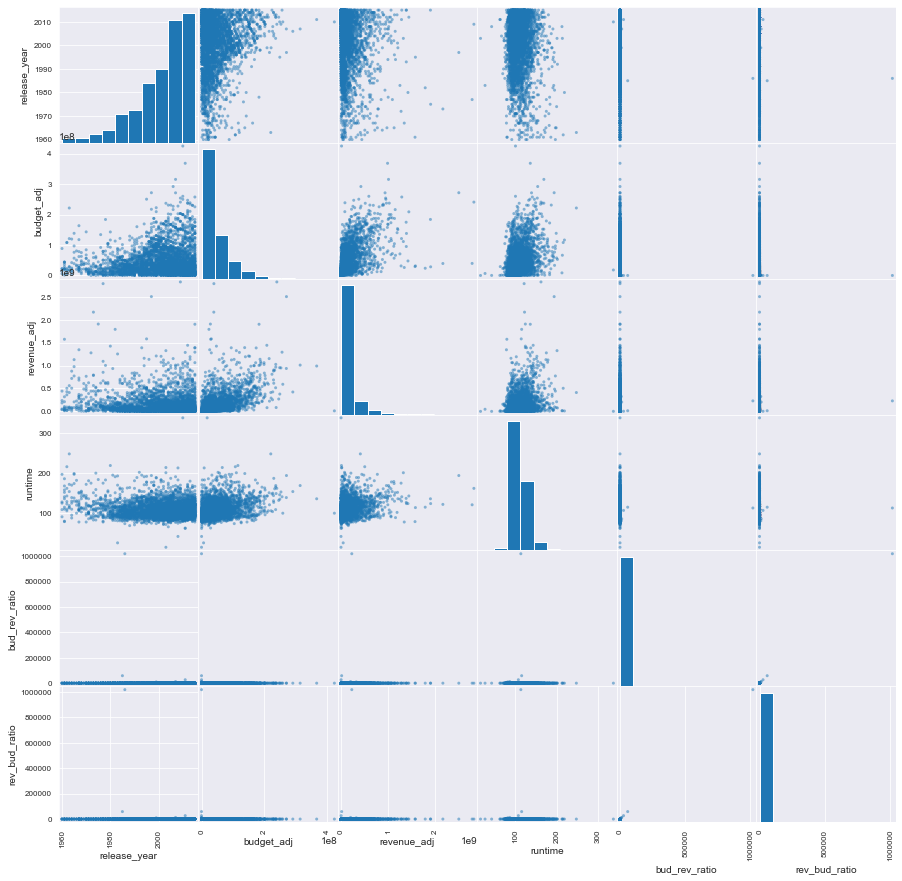

```python
# plotting a scatter matrix for budgets dataframe
pd.plotting.scatter_matrix(budgets, figsize=(15,15));
```

This visualization is informing and helps in having a general idea about how each variable relates to the others. but we can make a more pleasant one with the same above information plus grouping by each budget level, each with different color so that is easy to spot.

For this we will use seaborn `pairplot()` function which I found in seaborn [tutorial](https://seaborn.pydata.org/tutorial/axis_grids.html) page.

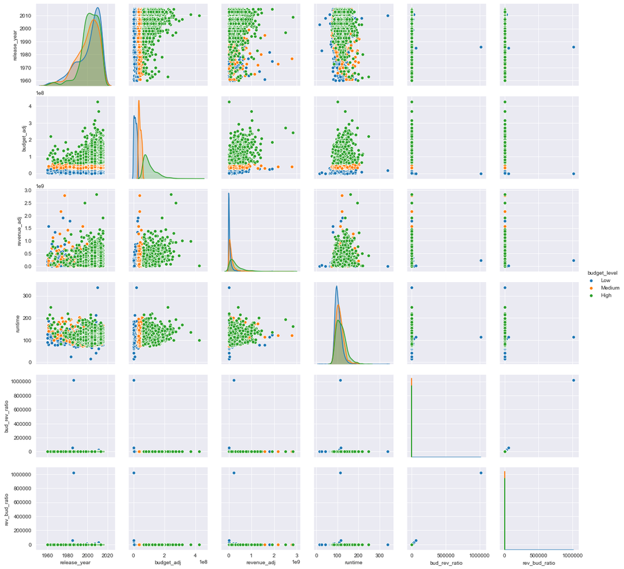

```python
# creating the pairplot
sns.pairplot(budgets, hue="budget_level", height=2.5);
```

This is much better now, now we need to concentrate on the relationship or the scatterplot between `revenue_adj` and `budget_adj`, so let's have a closer look.

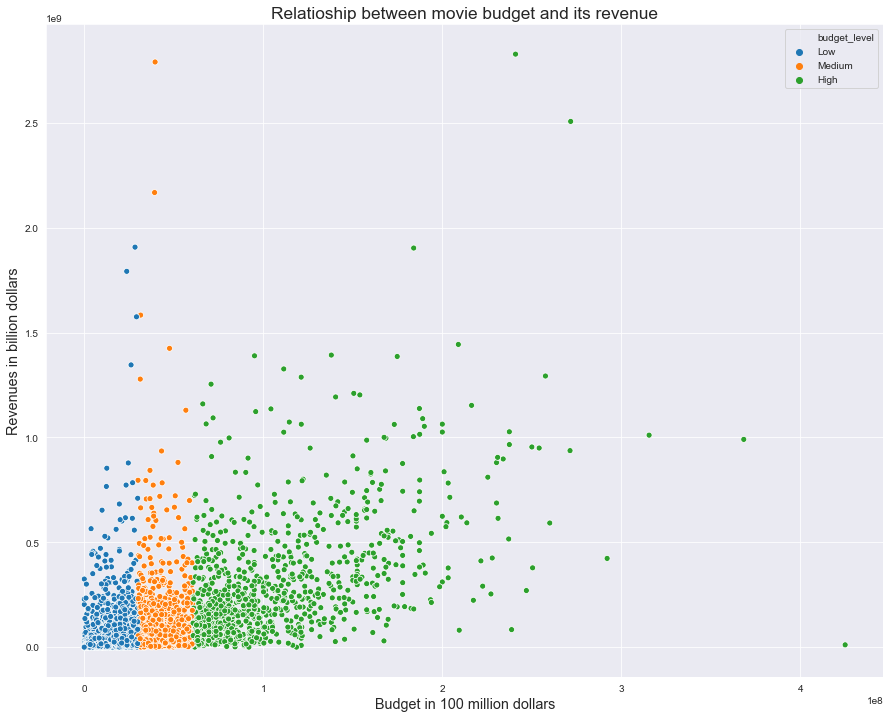

```python
# creating a scatterplot between revenue_adj and budget_adj
plt.figure(figsize=(15,12))
sns.scatterplot(x= budgets.budget_adj, y= budgets.revenue_adj,hue= budgets.budget_level)
plt.title('Relatioship between movie budget and its revenue', fontsize='xx-large' )
plt.xlabel('Budget in 100 million dollars', fontsize='x-large')
plt.ylabel('Revenues in billion dollars', fontsize='x-large');
```

From the scatterplot above we can see that there is a relationship but not that strong. the highest revenues comes from high budget movies, but there is also some low and medium budgets with high revenues.

Let's calculate the correlation coefficient between these two columns to be more precise. we will use pandas `.corr()`.

```python
# calculating the correlation coefficient
budgets['budget_adj'].corr(budgets['revenue_adj'], method='pearson')
```

```
0.5704510195812406
```

As we found above, the correlation coefficient show a positive but moderate relationship between the two.

Now let's visit the second part of our question..

we will create a mask with which we will filter the budgets dataframe to find the answer.

```python
# finding the movie with the highest revenue to budget ratio
max_ratio = budgets['rev_bud_ratio'] == budgets['rev_bud_ratio'].max()
budgets[max_ratio]
```

[output not shown]

The answer is : The Karate Kid, Part II

### 3. Does a movie runtime affect the revenue? and is the average movie runtime increasing over the years?

For the first part of the question let's make a scatterplot between `runtime` and `revenue_adj`. we had a glimpse at it in the pairplot in the previous question,but now let's have a more clear and focused look

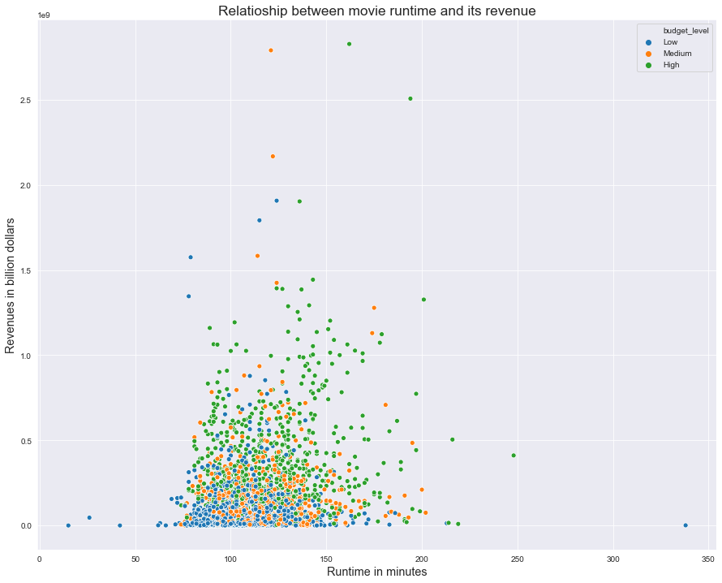

```python
# plotting the scatterplot
plt.figure(figsize=(15,12))
sns.scatterplot(x= budgets.runtime, y= budgets.revenue_adj,hue= budgets.budget_level)
plt.title('Relatioship between movie runtime and its revenue', fontsize='xx-large' )
plt.xlabel('Runtime in minutes', fontsize='x-large')
plt.ylabel('Revenues in billion dollars', fontsize='x-large');
```

Not much a relationship can be seen in the plot, but let's calculate the correlation coefficient.

```python
# calculating the correlation coefficient between runtime and revenue_adj
budgets['runtime'].corr(budgets['revenue_adj'], method='pearson')
```

```
0.280504777238597
```

The correlation coefficient indicates a positive but weak relationship between the two.

To answer the second part of the question, **is the average movie runtime increasing over the years?**, we need first to calculate the average movie runtime for each year. we will use pandas `.groupby` to group by `release_year` column.

```python
# calculating the average runtime for each year
run_time = budgets.groupby('release_year', as_index= False)['runtime'].mean()
run_time.head()
```

|  | release_year | runtime |
| --- | --- | --- |
| 0 | 1960 | 130.000000 |
| 1 | 1961 | 132.500000 |
| 2 | 1962 | 141.285714 |
| 3 | 1963 | 153.500000 |
| 4 | 1964 | 122.428571 |

Now that we have the average runtime for each year, we can now make our plot which will be a line chart to see change over time.

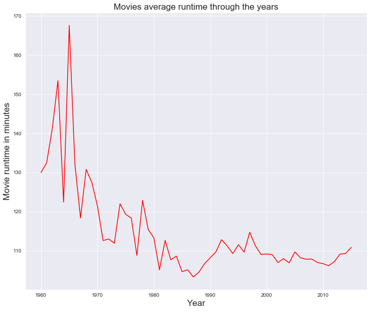

```python
# plotting the line chart
plt.figure(figsize=(12,10))
plt.plot(run_time['release_year'],run_time['runtime'], color='red')
plt.title('Movies average runtime through the years', fontsize='xx-large')
plt.xlabel('Year', fontsize='xx-large')
plt.ylabel('Movie runtime in minutes', fontsize='xx-large');
```

From the above chart, we can see how the average movie runtime is decreasing over the years.

### 4. Who is the most accomplished director in terms of total revenues and total average scores of his movies?

Let's break this question into two parts:

- In terms of total revenues
- In terms of total average scores

#### most accomplished director in terms of total revenues

We will group by `director` column and then sum the total revenues for each one.

```python
# calculating the total revenue for each director
director_revenue = df_mod.groupby('director', as_index= False)['revenue_adj'].sum()
director_revenue
```

|  | director | revenue_adj |
| --- | --- | --- |
| 0 | Frédéric Jardin | 3.255239e+03 |
| 1 | A. Todd Smith | 0.000000e+00 |
| 2 | A.R. Murugadoss | 7.697178e+07 |
| 3 | Aaron Aites | 0.000000e+00 |
| 4 | Aaron Blaise\|Robert Walker | 2.963382e+02 |
| ... | ... | ... |
| 5051 | ÇaÄŸan Irmak | 0.000000e+00 |
| 5052 | Émile Gaudreault | 3.593753e+06 |
| 5053 | Éric Besnard | 0.000000e+00 |
| 5054 | Étienne Chatiliez | 0.000000e+00 |
| 5055 | Àlex Pastor\|David Pastor | 5.897584e+06 |

5056 rows × 2 columns

to find the one with the highest total revenues we will create a mask and then filter our dataframe and see.

```python
# finding which director has highest total revenue
max_revenue = director_revenue['revenue_adj'] == director_revenue['revenue_adj'].max()
director_revenue[max_revenue]
```

|  | director | revenue_adj |
| --- | --- | --- |
| 4593 | Steven Spielberg | 1.520245e+10 |

The answer is : Steven Spielberg

#### most accomplished director in terms of total average scores

We will group by `director` and then calculate the mean for `vote_average` for each one.

```python
# calculating the average voting scores for each director
director_score = df_mod.groupby('director', as_index= False) ['vote_average'].mean()
director_score
```

[output not shown]

to find the one with the highest average scores we will create a mask and then filter our dataframe.

```python
# finding which director has highest voting score
max_score = director_score['vote_average'] == director_score['vote_average'].max()
director_score[max_score]
```

|  | director | vote_average |
| --- | --- | --- |
| 3109 | Mark Cousins | 9.2 |

The answer is : Mark Cousins

### 5. Who are the most productive directors in terms of number of movies made?

To answer this question we will first group by `director` and then count the number of movies for each one.

```python
# calculating number of movies for each director
director_movies = df_mod.groupby('director', as_index= False)['original_title'].count()
director_movies
```

|  | director | original_title |
| --- | --- | --- |
| 0 | Frédéric Jardin | 1 |
| 1 | A. Todd Smith | 1 |
| 2 | A.R. Murugadoss | 1 |
| 3 | Aaron Aites | 1 |
| 4 | Aaron Blaise\|Robert Walker | 1 |
| ... | ... | ... |
| 5051 | ÇaÄŸan Irmak | 1 |
| 5052 | Émile Gaudreault | 1 |
| 5053 | Éric Besnard | 1 |
| 5054 | Étienne Chatiliez | 3 |
| 5055 | Àlex Pastor\|David Pastor | 1 |

5056 rows × 2 columns

Now let's see who is the one with the highest number of movies made.

```python
# finding which director has the highest number of movies made
max_movies = director_movies['original_title'] == director_movies['original_title'].max()
director_movies[max_movies]
```

|  | director | original_title |
| --- | --- | --- |
| 4989 | Woody Allen | 45 |

ok it's Woody Allen with a total of 45 movies made. now let's have a summary of our movie counts.

```python
# summary stats for movie counts for directors.
director_movies.describe()
```

|  | original_title |
| --- | --- |
| count | 5056.000000 |
| mean | 2.136076 |
| std | 2.526159 |
| min | 1.000000 |
| 25% | 1.000000 |
| 50% | 1.000000 |
| 75% | 2.000000 |
| max | 45.000000 |

The above summary shows that a three quarters of the directors in this dataset made at most 2 movies! to find the top directors in the remaining quarter we will look for the ones who made at least half the number of movies made by the most productive one.

```python
# top productive directors
high_movies = (director_movies.original_title >= 23) & (director_movies.original_title <= 45)
top_productive = director_movies[high_movies]
top_productive
```

|  | director | original_title |
| --- | --- | --- |
| 876 | Clint Eastwood | 34 |
| 3168 | Martin Scorsese | 29 |
| 4025 | Ridley Scott | 23 |
| 4593 | Steven Spielberg | 29 |
| 4989 | Woody Allen | 45 |

And here they are! our top 5 most productive directors. now let's have our bar chart.

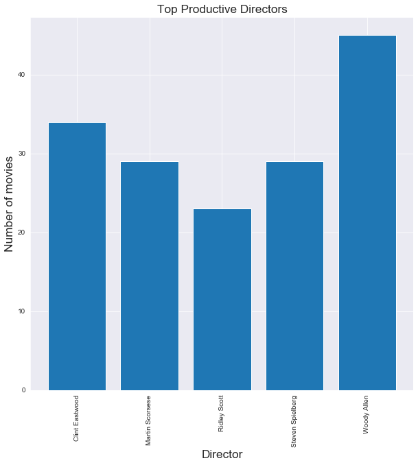

```python
# plotting the bar chart
names = top_productive.director
number = top_productive.original_title
plt.figure(figsize=(10,10))
plt.bar(names, number)
plt.title('Top Productive Directors', fontsize='xx-large')
plt.xlabel('Director', fontsize='xx-large')
plt.ylabel('Number of movies', fontsize='xx-large')
plt.xticks(rotation='vertical');
```

From the bar chart we see that we have Woody Allen at the top followed by Clint Eastwood then we have a draw between Martin Scorsese and Steven Spielberg then at number 5 we have Ridley Scott with 23 movies.

## Conclusions

And here now we are going to conclude and summarize the results of our performed investigation and answer the questions posed at the begining:

## Limitations

Our above conclusions should be taken with a grain of salt due to some factors we already came across during our analysis but which we are going to state here as a reminder:

1. This dataset is not equally representative of movies in different years, with the majority of the movies included falling after 2000s. This was clearly seen in the distribution of the `release_year` column. our first question is the one that is greatly impacted due to this.
1. The number of the missing values (the high number of zeros) in both the budget and revenue columns was too high, and this made us work with what we could call a sample from these columns because we couldn't afford to have any zeros in our analysis. our second and third questions are the ones most affected because of this.